# Homework 5: Version Control, Containerization, and HPC

## Question 3.4: Submit, Verify, and Version Control (3 points)

**a)** (1 point) What command did you use to submit your job to Slurm?

**Answer:**

```bash
# Command here
sbatch run_compute_bench.sh
```

**b)** (2 points) Provide the output of your job. Paste the contents of your Slurm output file (e.g., `slurm-jobid.out`). Also, add your Slurm script (`run_compute_bench.sh`) to your GitHub repository and push it.

**Job Output:**

```
# Paste your job output here

Job started on Fri Nov 14 12:53:50 AM EST 2025
Running on node: g0602.ll.unc.edu
Job ID: 21994427
Fri Nov 14 00:53:50 2025
+-----------------------------------------------------------------------------------------+
| NVIDIA-SMI 580.95.05              Driver Version: 580.95.05      CUDA Version: 13.0     |
+-----------------------------------------+------------------------+----------------------+
| GPU  Name                 Persistence-M | Bus-Id          Disp.A | Volatile Uncorr. ECC |
| Fan  Temp   Perf          Pwr:Usage/Cap |           Memory-Usage | GPU-Util  Compute M. |
|                                         |                        |               MIG M. |
|=========================================+========================+======================|
|   0  NVIDIA GeForce GTX 1080        On  |   00000000:85:00.0 Off |                  N/A |
| 27%   30C    P8              6W /  180W |       3MiB /   8192MiB |      0%      Default |
|                                         |                        |                  N/A |
+-----------------------------------------+------------------------+----------------------+

+-----------------------------------------------------------------------------------------+
| Processes:                                                                              |
|  GPU   GI   CI              PID   Type   Process name                        GPU Memory |
|        ID   ID                                                               Usage      |
|=========================================================================================|
|  No running processes found                                                             |
+-----------------------------------------------------------------------------------------+
GPU available: NVIDIA GeForce GTX 1080

CPU Computations:
Time for 10,000,000 elements: 0.1934 seconds
Time for 100,000,000 elements: 1.5580 seconds

GPU Computations:
Time for 10,000,000 elements: 4.1265 seconds
Time for 100,000,000 elements: 0.0061 seconds

Small sample of 10 random numbers:
tensor([ 0.3367,  0.1288,  0.2345,  0.2303, -1.1229, -0.1863,  2.2082, -0.6380,
         0.4617,  0.2674])

Saved data to mydata.pt
Job completed on Fri Nov 14 12:54:00 AM EST 2025
```

**GitHub Verification:** ✓ Pushed `run_compute_bench.sh` to repository

**c)** (BONUS: +2 points) Include a screenshot showing your job in the Slurm queue or completed job information using `squeue` or `sacct`. Also show that your job successfully utilized a GPU (if you requested one).

```bash
(base) [gyuan@g0601 stor674-homework5]$ squeue -u $USER
             JOBID PARTITION     NAME     USER ST       TIME  NODES NODELIST(REASON)
          21994427       gpu compute_    gyuan PD       0:00      1 (Priority)


(base) [gyuan@g0601 stor674-homework5]$ sacct -j 21994427 --format=JobID,JobName,Partition,State,ExitCode,Elapsed,ReqTRES
JobID           JobName  Partition      State ExitCode    Elapsed    ReqTRES
------------ ---------- ---------- ---------- -------- ---------- ----------
21994427     compute_b+        gpu  COMPLETED      0:0   00:00:11 billing=1+
21994427.ba+      batch             COMPLETED      0:0   00:00:11
21994427.ex+     extern             COMPLETED      0:0   00:00:11
```

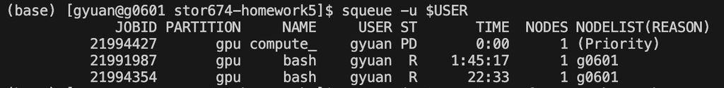

squeue -u $USER

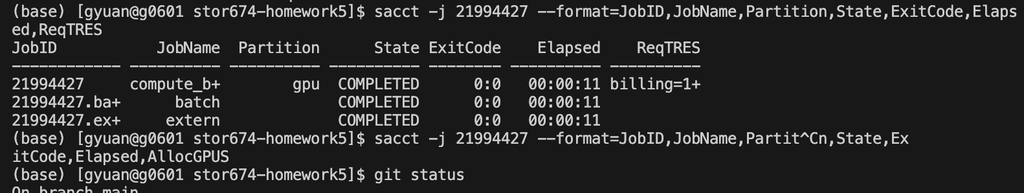

sacct

# Part 4: Reflection and Best Practices (Optional - Extra Credit: 5 points)

**Question 4.1:** Reflect on the workflow you just completed (Git → Docker → HPC). How does this approach improve reproducibility in computational research? What are some advantages and potential challenges?

**Answer:**

it improves computational research reproducibility through several mechanisms: Advantages:

Version Control (Git): Tracks all code changes, enabling researchers to reproduce exact versions of experiments and collaborate effectively across time and teams.

Environment Consistency (Docker/Apptainer): Containers package the entire computational environment including OS, libraries, and dependencies, eliminating “works on my machine” issues. The same container runs identically on a laptop or HPC cluster.

Researchers can develop locally and scale to HPC resources seamlessly.

Resource Efficiency: HPC integration through Slurm enables access to powerful GPU resources while containers ensure optimal utilization regardless of the host system configuration.

Reproducibility Chain: Anyone can clone the Git repo, pull the Docker image, and reproduce results exactly, even years later when system libraries have changed.

Challenges:

Architecture Compatibility: As experienced with ARM64 vs AMD64, multi-architecture support requires careful consideration.

Learning Curve: Researchers need to learn Git, containerization, and HPC job scheduling - a significant initial investment.

Storage Overhead: Container images can be large, and maintaining multiple versions consumes significant storage.

## Security Constraints: HPC systems often use Singularity/Apptainer instead of Docker for security, requiring workflow adaptation.

# Submission Checklist

Before submitting, make sure you have:

- Completed all questions in Part 1 (Git/GitHub concepts)
- **Created a GitHub repository with all your project files**
- **Practiced branching and merging in your Git workflow**
- Created a Dockerfile with CUDA support for GPU computing
- Built and tested your Docker image locally (Linux container on macOS/Windows)
- Pushed your image to Docker Hub
- Provided your Docker Hub image URL
- Created a Slurm job script
- Successfully ran your job on Longleaf
- **Pushed all files (Dockerfile, Slurm script, completed Rmd) to GitHub**
- Included all output and screenshots
- Compiled this Rmd file to HTML or PDF

**Submission Instructions:**

1. **Ensure your GitHub repository contains:**
   - `Dockerfile`
   - `compute_bench.py`
   - `run_compute_bench.sh` (Slurm script)
   - `Homework5.Rmd` (completed)
   - Evidence of branching/merging in commit history
2. Submit the knitted HTML/PDF file on Canvas
3. **Submit the link to your GitHub repository on Canvas (REQUIRED)**
4. Submit the link to your Docker Hub image on Canvas

# Grading Rubric

| Section | Points |
| --- | --- |
| Part 1: Git and GitHub Concepts | 20 |
| Part 2: Docker with Version Control (includes branching/merging) | 50 |
| Part 3: Apptainer and Slurm on Longleaf | 30 |
| **Total** | **100** |
| Extra Credit (Part 4: Reflection) | +5 |
| Extra Credit (Part 3.4c: GPU screenshot) | +2 |
| **Maximum Possible** | **107** |

# Resources

- [Git Branching Documentation](https://git-scm.com/book/en/v2/Git-Branching-Branches-in-a-Nutshell)
- [Docker Hub](https://hub.docker.com/)
- [Apptainer Documentation](https://apptainer.org/docs/)
- [Longleaf Documentation](https://help.rc.unc.edu/longleaf-cluster/)
- Course lecture materials on GitHub, Docker, and Apptainer

**Good luck!**